# Exploratory Data Analysis

CSULB Intro to R

April 27, 2018

## Agenda

1. Brief Review
2. Exploratory Data Analysis
   - Numeric Summary Statistics
   - Histograms
   - Boxplots
   - Scatterplot Matrices

## Vector and Matrix Review

- Vectors and Matrices are data structures used to hold data of the same type
  - `myVec <- c(1,2,3)`
  - `myMatrix <- matrix(c('Ariel', 'Bill', 'Chris', 'Devon',` `ncol=3, nrow=2)`
- If the data is not of the same type, R will **coerce** the data to the most flexible type
- We subset these structures using the `[]` operator
  - `myVec[2]`, `myVec[-3]`, `myVec[myVec >= 2]`
  - `myMatrix[2,1]`, `myMatrix[3,]`, `myMatrix[,1]`

## Data Frame Review

- Data Frames are special lists in R that hold different data types
  - `myDF <- data.frame(names=c('Albert', 'Bianca', 'Cat'),` `height=c(71, 57, 64),` `female=c(0,1,1))`
- Each column must be the same length and must have the same data type within that column
- We subset (named) data frames using the `$` operator. This can be combined with the `[]` operator.
  - `myDF$names`
  - `myDF$height[myDF$height > 60]`
  - `myDF$height[myDF$female==1]`

## Function Review

- Functions, `function()`, are blocks of code or instructions that take some input and produce a desired output.
- The input is known as the arguments or parameters
- In R, many functions have preset/default argument values so that you don’t have to specify them each time. However, it’s usually good practice to specify several arguments to make your output more readable.

## Reading Data

- Before beginning a data analysis, we need to read in the appropriate data
- This is generally handled with 1 of 2 functions: `read.table()`, or `read.csv()`
- [Auto MPG data](https://archive.ics.uci.edu/ml/machine-learning-databases/auto-mpg/auto-mpg.data)
  - `autos <-` `read.table(file='https://archive.ics.uci.edu/ml/` `machine-learning-databases/auto-mpg/auto-mpg.data',` `header=FALSE)`
- [Abalone Whale Data](https://archive.ics.uci.edu/ml/machine-learning-databases/abalone/abalone.data)
  - `whales <-` `read.csv(file='https://archive.ics.uci.edu/ml/` `machine-learning-databases/abalone/abalone.data',` `header=FALSE)`

## Writing Data

- Writing data is useful when you need to save a copy of your dataset to your local machine
- This is usually done with `write.table()` and `write.csv()`
  - `write.table(object, filename, sep)`
  - `write.csv(object, filename)`

## Some Useful Functions

- `str()`: a function to explain internal structure of an object
- `summary()`: a function that summarizes variables in a data frame
  - Note: this function is also used to summarize results of model fitting functions, which we will go over in the afternoon.

## `str()`

Compact way of understanding what an object is and what it contains

```r
str(mean)
```

```
## function (x, ...)
```

```r
str(matrix)
```

```
## function (data = NA, nrow = 1, ncol = 1, byrow = FALSE, dimnames = NULL)
```

```r
str(sample)
```

```
## function (x, size, replace = FALSE, prob = NULL)
```

## `str()`

After loading a data frame, it is often useful to use `str()` in order to understand the structure of your data.

```r
str(myDF)
```

```
## 'data.frame':    3 obs. of  3 variables:
##  $ names : Factor w/ 3 levels "Albert","Bianca",..: 1 2 3
##  $ height: num  71 57 64
##  $ female: num  0 1 1
```

```r
prestige <- read.table(file = here::here("data", "prestige_v2.csv"),
                       sep=",",
                       header=TRUE,
                       row.names=1)
str(prestige)
```

```
## 'data.frame':    101 obs. of  6 variables:
##  $ education: num  13.1 12.3 12.8 11.4 14.6 ...
##  $ income   : int  12351 25879 9271 8865 8403 11030 8258 14163 11377 11023 ...
##  $ women    : num  11.16 4.02 15.7 9.11 11.68 ...
##  $ prestige : num  68.8 69.1 63.4 56.8 73.5 77.6 72.6 78.1 73.1 68.8 ...
##  $ census   : int  1113 1130 1171 1175 2111 2113 2133 2141 2143 2153 ...
##  $ type     : Factor w/ 3 levels "bc","prof","wc": 2 2 2 2 2 2 2 2 2 2 ...
```

## `summary()`

Another useful function for understanding your data by providing a numeric summary of each attribute (column).

```r
summary(prestige)
```

```
##    education         income          women          prestige
##  Min.   : 6.38   Min.   :  611   Min.   : 0.00   Min.   :14.80
##  1st Qu.: 8.43   1st Qu.: 4075   1st Qu.: 3.59   1st Qu.:35.20
##  Median :10.51   Median : 5902   Median :13.62   Median :43.50
##  Mean   :10.73   Mean   : 6784   Mean   :29.19   Mean   :46.76
##  3rd Qu.:12.71   3rd Qu.: 8131   3rd Qu.:52.27   3rd Qu.:59.60
##  Max.   :15.97   Max.   :25879   Max.   :97.51   Max.   :87.20
##      census       type
##  Min.   :1113   bc  :47
##  1st Qu.:3117   prof:31
##  Median :5137   wc  :23
##  Mean   :5422
##  3rd Qu.:8313
##  Max.   :9517
```

## Exploratory Data Analysis

- Before performing statistical analyses on your data, it is important to do exploratory data analysis (EDA) in order to better understand the variables and the relationships between them.
- This can be done in many ways
  - Numeric summaries (e.g., using `str()` and `summary()`)
  - Plots, plots, and more plots
  - More advanced methods (variograms, empirical covariance matrices, etc)
- We will cover some of the basic plotting functions.

## Plotting in R

- To explore the distribution of one variable:
  - 5-number summary
  - Boxplots
  - Histograms and Density Estimation
  - Violin plots
- To explore relationships between variables:
  - Grouped Violin Plots
  - Scatterplots
  - Scatterplot Matrices

## Useful plotting resources:

- [Quick-R Graphical Parameters](https://www.statmethods.net/advgraphs/parameters.html)
- [Colors in R](http://www.stat.columbia.edu/~tzheng/files/Rcolor.pdf)
- [Points and Line Types](http://www.cookbook-r.com/Graphs/Shapes_and_line_types/)
- [`ggplot2`](http://ggplot2.tidyverse.org/)
- Search for (or post) specific questions on [stackoverflow](https://stackoverflow.com/questions/tagged/r), which is a community that will answer questions & chose the best solutions via voting
- *NOTE: This course provides a basic introduction to `R`’s plotting capabilities. You can do much, much more elegant plots in `R`!*

## 5 number summary

- As seen in the `summary()` function, the distribution of a single numeric variable can be summed up wth 5 numbers. These are the minimum and max values, the $1^{st}$ and $3^{rd}$ quartiles (25% and 75%), and the median (50%).
- R also throws in the mean to create a “6 number summary.” We will focus on the 5 without the mean.

```r
summary(prestige$prestige)
```

```
##    Min. 1st Qu.  Median    Mean 3rd Qu.    Max.
##   14.80   35.20   43.50   46.76   59.60   87.20
```

## Box plots

- A box plot, `boxplot()`, is a handy graphical representation of the 5 number summary.
- Just as with the 5 number summary, the box plot tells us the min$^*$ and max$^*$ values, the $1^{st}$ and $3^{rd}$ quartiles, and the median.
  - If outliers are present, by default defined as outside of 1.5$\times$*inter-quartile range*, they will be shown outside of the whiskers.

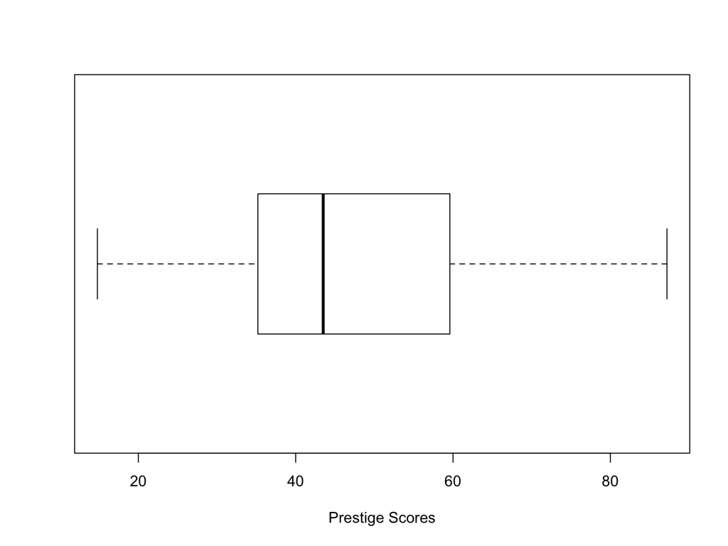

```r
boxplot(prestige$prestige, horizontal=TRUE, xlab='Prestige Scores')
```

## Histograms

- Another useful graphic to visualize the distribution of a variable is a histogram, `hist()`.
- Reduced version of a “stem-and-leaf” plot
- For each possible value of your variable (x-axis), a histogram displays the number of times that value appears in your data (y-axis). Counts can also be converted into proportions.
- This is a natural plot for a discrete variable. For continuous variables, a histogram “bins” the observations into discrete units/intervals.

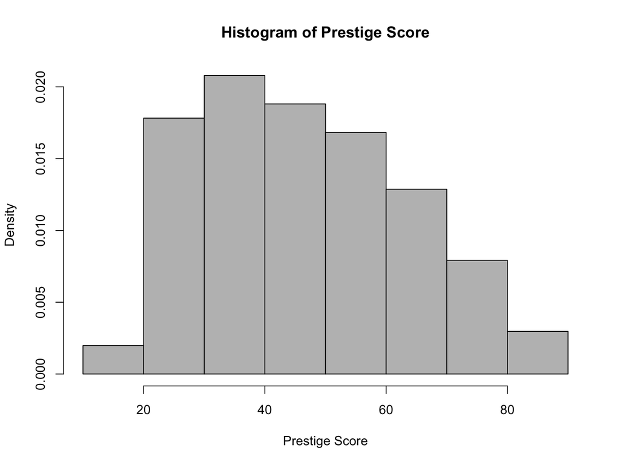

```r
hist(prestige$prestige, freq = FALSE,
     col = "grey",
     main = "Histogram of Prestige Score",
     xlab = "Prestige Score")
```

## Histograms, contd.

- Sometimes we would rather have a smoothed version of a histogram (i.e., a *density* function).
  - Not susceptible to number/location of bins like histograms are.
- We can include this using the `density()` and `lines()` functions.
  - `lines()`: takes coordinate pairs (in multiple input formats) and adds them to current figure connected by line segments
  - `density()`: computes kernel density estimates (a smoothed histogram); see `?density` for more details

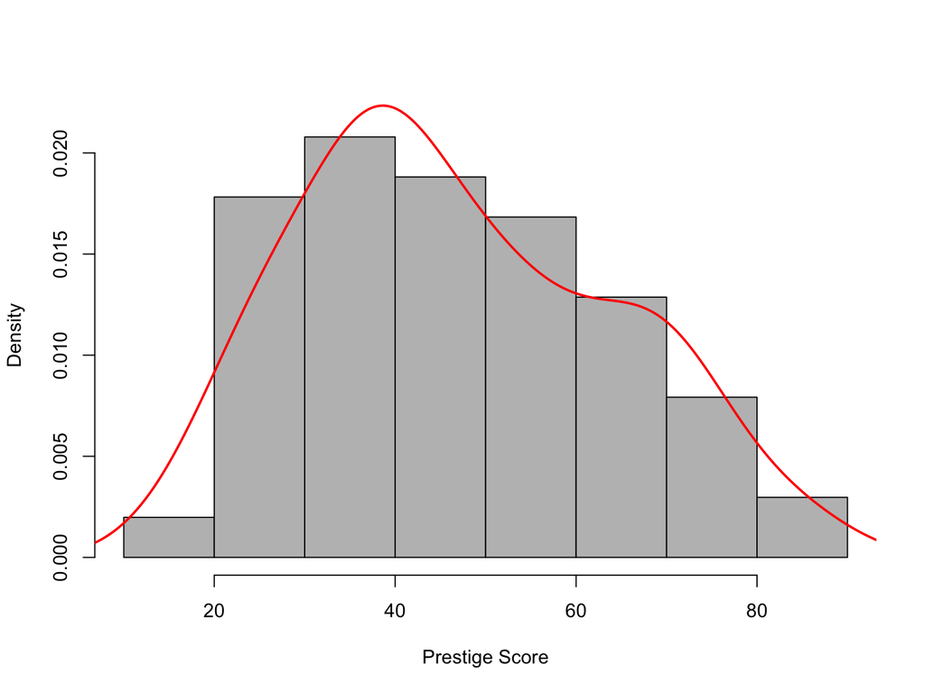

```r
hist(prestige$prestige, freq=FALSE, col = "grey", main = "", xlab = "Prestige Score", ylim=c(0,0.022))
lines(density(prestige$prestige, bw='nrd0'), col = "red", lwd = 2)
```

## Violin Plots

- So far we’ve seen how a distribution can be summarized by a 5 number summary, which can be visualized with a box plot.
- We’ve also seen how to view the shape of a distribution using histograms and density estimates.
- 🤔 Can we combine these into one graphic?
  - Obviously. We made a whole slide for it.
- Violin plots create boxplots, but overlay them with a mirrored density estimate

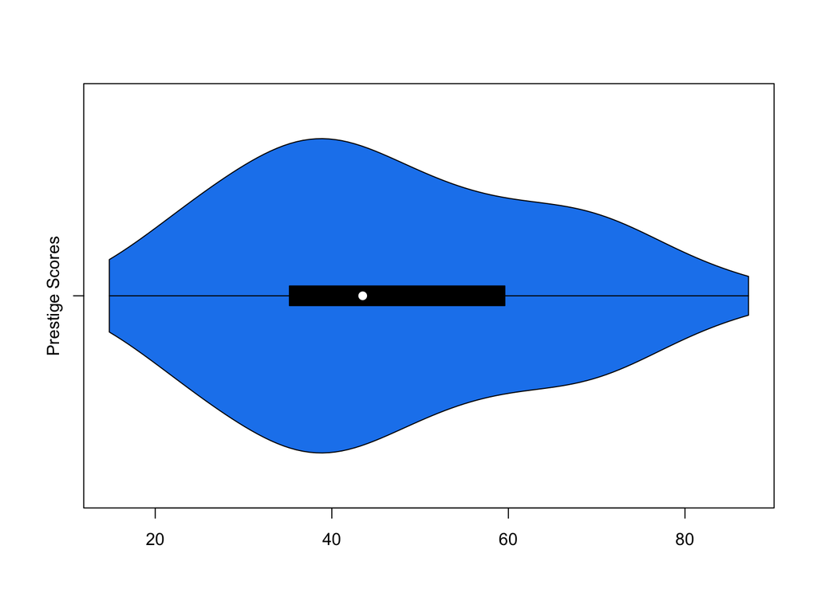

```r
vioplot(prestige$prestige, horizontal=TRUE, col='dodgerblue2',
  names='Prestige Scores')
```

## Exploring more than one variable

- We’ve looked at ways to view the distribution of single variables, but how do we examine the relationship between 2 variables? 3? 42?
- We’ll focus on 2 for now.
- Types of relationships:
  - Discrete - Discrete
  - Discrete - Continuous
  - Continuous - Continuous

## Discrete - Discrete

- Many times, we’ll be interested in a discrete response across classes of subjects, e.g. proportion of smokers to non-smokers across males/females.
- This can usually be summed up with a table

|  | Male | Female |
| --- | --- | --- |
| Smoke | 16% | 12% |
| Nah | 41% | 31% |

- We could also overlay histograms, though this is more beneficial for ordered factors or continuous covariates.

## Overlay Histograms

- For Discrete - Continuous types
- When examining the distribution of a single variable, we can easily create a histogram using `hist()`. We can extend this to creating a histogram of a single variable, but for multiple groups.
- Let’s examine the `prestige` scores grouped by `type`.

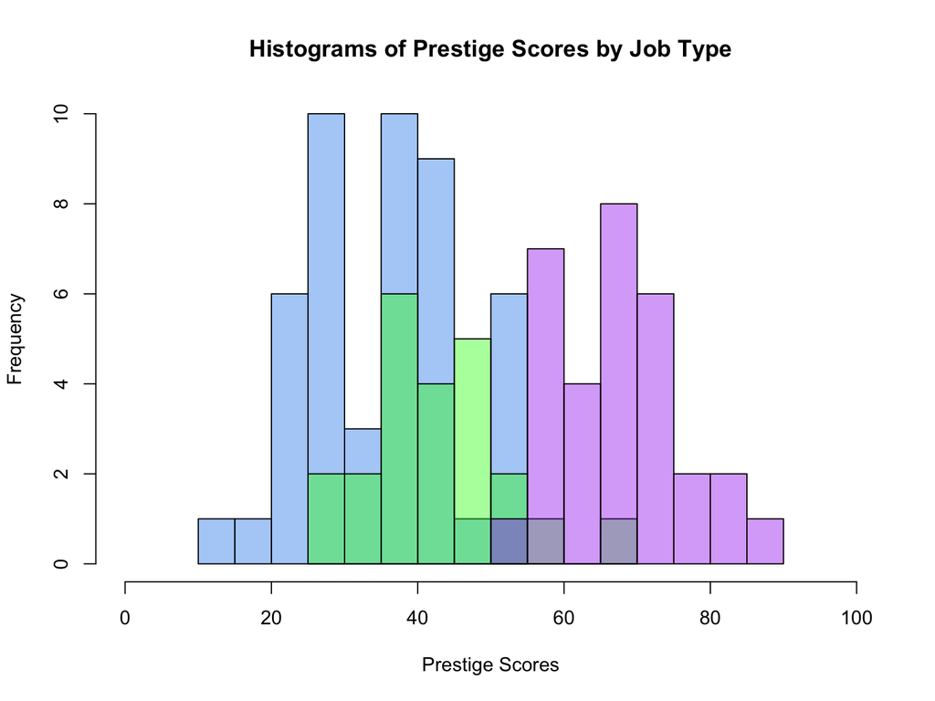

```r
pp <- prestige$prestige
hist(pp[prestige$type=='bc'], breaks=10, main='Histograms of Prestige Scores by Job Type',
  xlab='Prestige Scores', col=adjustcolor('dodgerblue2',.4), xlim=c(0,100))
hist(pp[prestige$type=='wc'], breaks=10, col=adjustcolor('green', .4), add=TRUE)
hist(pp[prestige$type=='prof'], breaks=10, col=adjustcolor('purple', .4), add=TRUE)
```

## Adding Lines

- While looking at these histograms (or any plot for that matter), we may wish to add lines indicating the location of the mean, median, quartiles, etc.
- We can do this using the `abline()` function.
- With `abline()`, we can plot a vertical line, `abline(v=...)`, horizontal line, `abline(h=...)`, generic lines, `abline(a=intercept, b=slope,...)`, and others.

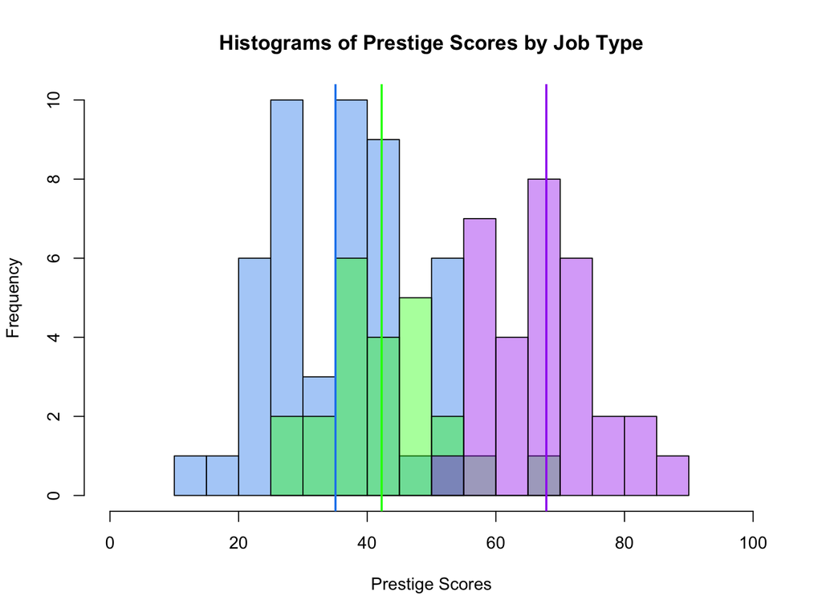

```r
abline(v=mean(pp[prestige$type=='bc']), lwd=2, col='dodgerblue2')
abline(v=mean(pp[prestige$type=='wc']), lwd=2, col='green')
abline(v=mean(pp[prestige$type=='prof']), lwd=2, col='purple')
```

## Adding a Legend

- With multiple features on one figure, a legend can help clearly convey what is plotted.
- Use `legend()` to do this in R.
  - Very versatile function–look at its documentation
  - Best to play around with this on your own, iterating through multiple plots until you get the legend to appear how you want it

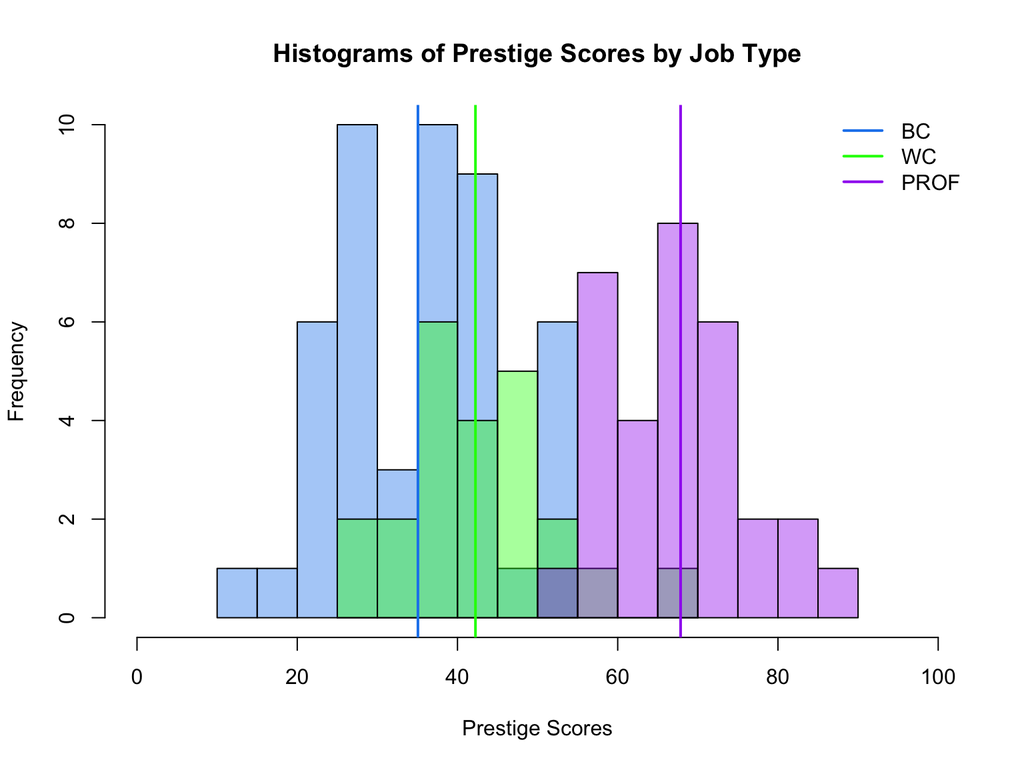

```r
legend("topright", legend = c("BC", "WC", "PROF"),
       col = c("dodgerblue2", "green", "purple"), lty = 1, lwd = 2, bty = "n")
```

## Grouped Violin plots

- Used to investigate relationships between variables:
  - Continuous variable & factor (most common)
  - Two continuous variables (group one of them)
- Let’s look at violin plots of `prestige` grouped by `type`

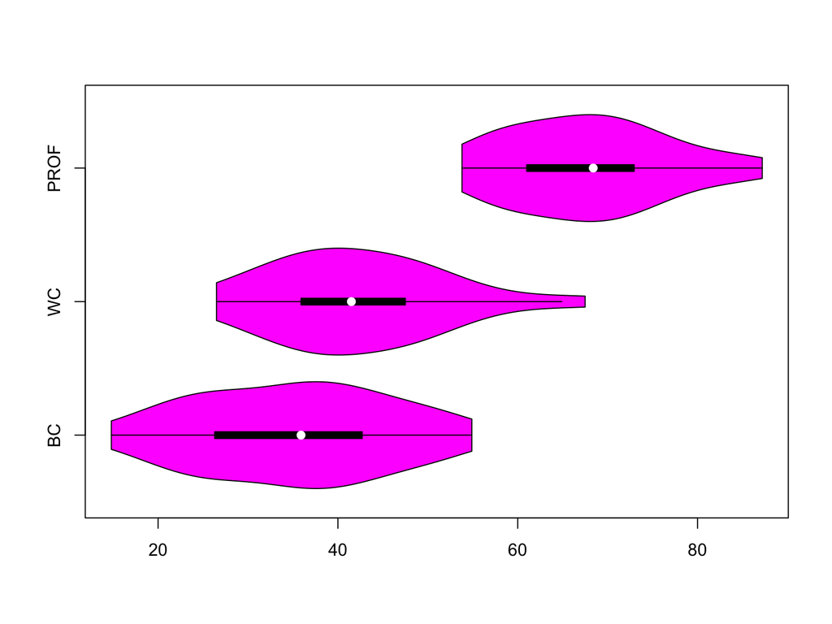

```r
vioplot(pp[prestige$type=='bc'], pp[prestige$type=='wc'], pp[prestige$type=='prof'],
  horizontal=TRUE, names=c('BC', 'WC', 'PROF'))
```

## Scatterplots

- We can also use scatterplots to visualize the relationship between two (continuous) variables.
- We use the `plot()` function to do this
  - Extremely flexible–there are plot methods for a variety of objects! (e.g., plotting a regression object returns diagnostic plots… more on this later)
  - See the help documentation (`?plot`) and [Graphical Parameters](https://www.statmethods.net/advgraphs/parameters.html) for more details
- For now, focus on the most simple plot where we specify the `x` and `y` coordinates.
  - `x` and `y` must be the same dimension

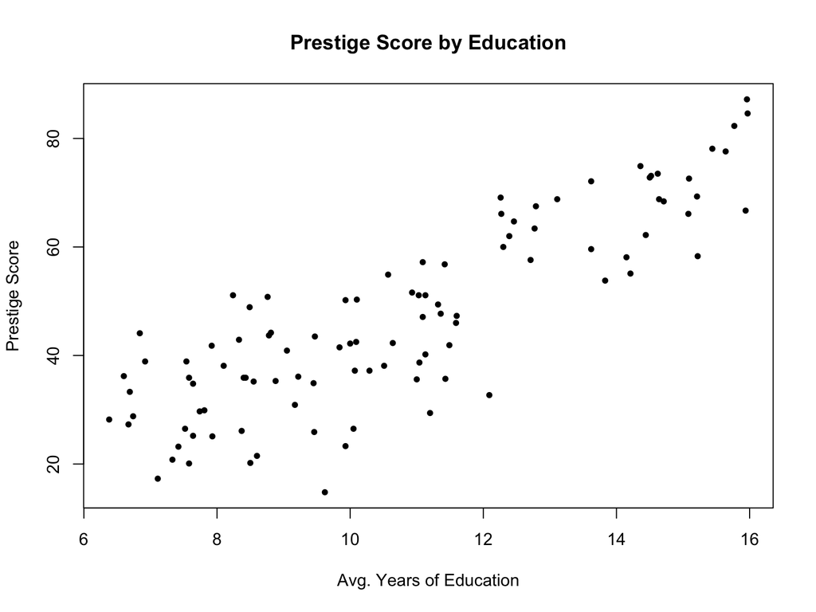

```r
plot(x = prestige$education, y = prestige$prestige, pch = 20,
     main = "Prestige Score by Education",
     xlab = "Avg. Years of Education", ylab = "Prestige Score")
```

## Scatterplots, contd.

- Let’s overlay both a linear fit and smoother to our scatterplot.
- We can include this using the `lowess()`, `lines()`, and `abline()` functions.
  - Need to use `lm()` to fit a linear regression, more on this later
  - `lowess()`: **LO**cally **WE**ighted **S**catterplot **S**moother; computes a smoothed fit using locally-weighted polynomial regression.

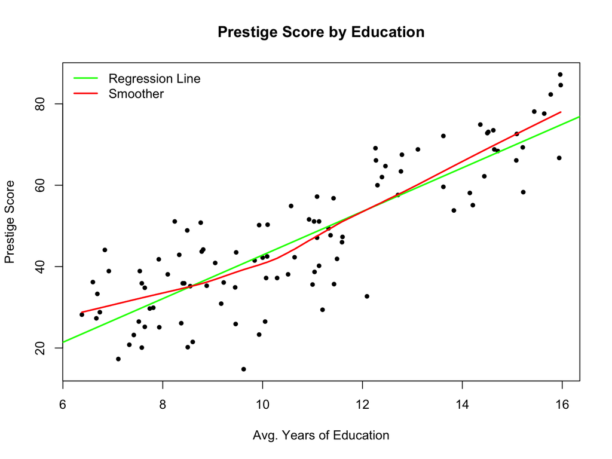

```r
plot(prestige$education, prestige$prestige, pch = 20,
     main = "Prestige Score by Education",
     xlab = "Avg. Years of Education", ylab = "Prestige Score")

abline(reg = lm(prestige ~ education, data = prestige),
  col = "green", lwd = 2)  # linear regression

lines(lowess(x = prestige$education, y = prestige$prestige),
  col = "red", lwd = 2)  # smoother

legend("topleft", legend = c("Regression Line", "Smoother"),
  col = c("green", "red"), lwd = c(2,2), lty = 1, bty = "n")
```

## Scatterplot Matrices

- The function `scatterplotMatrix()` (found in the `car` package we installed earlier) produces scatterplots between all variables in a data frame.
- We can use direct ordering of the variables to control the order in which they are plotted.

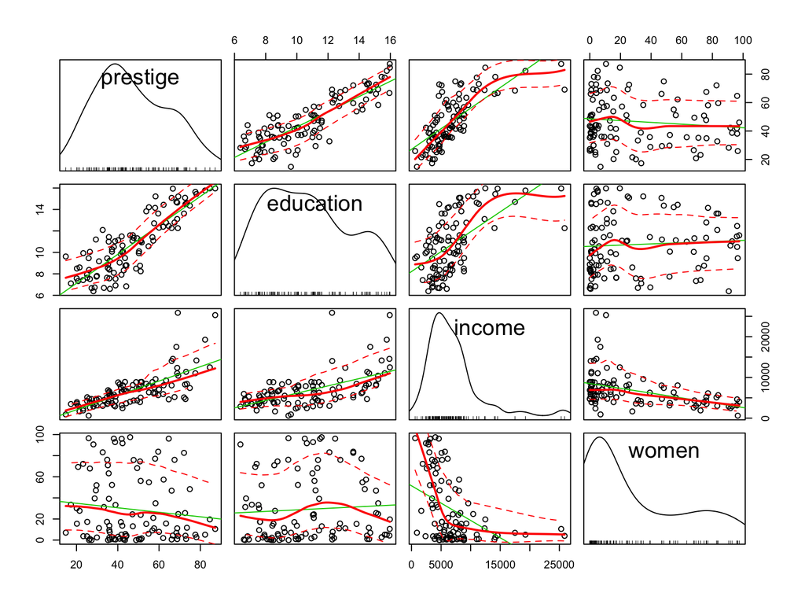

```r
library(car)
scatterplotMatrix( prestige[ ,c("prestige","education","income","women")] )
```

## Summary

- We’ve seen how to explore single variables with boxplots, histograms and density estimatates, and a combination of these known as a violin plot.
- For 2 variables, we created grouped violin plots, overlayed histograms, and scatterplots.
- Visualizations can be enhanced by adding lines, colors, labels, etc
- There is always more than one way to view your data. Each perspective can give you a new understanding.

## Some common commands and arguments

- Plots
  - `boxplot()`
    - horizontal=TRUE
  - `hist()`
    - freq=TRUE
  - `density()`
    - bw=c(‘nrd0’, ‘SJ’, 5, 0.5,…)
  - `vioplot::vioplot()`
    - horizontal=TRUE, names=c(‘name1’, ‘name2’,…)
  - `plot()`
- Common plot arguments (for **most** plots)
  - labeling: main, xlab, ylab
  - limits: xlim, ylim
  - add to existing plot: add=TRUE
  - point and line types and shapes: pch, lty, lwd
  - color: col
- Other useful functions
  - To add curves to existing plot: `lines()`
  - To add straight line to existing plot: `abline()`
  - To adjust color transparency: `adjustcolor()`

## Next up

1. [Exercise 1](https://datumu.github.io/CSULB_Intro_R/day_2/exercises/exercise_1/ex_1.html)
2. Lunch